# Cluster analysis for brain region

2024-11-25

This is document to create cluster image on Figure 4C_brain.

To ensure that all input and output files are correctly accessed and saved, we specify the working directory where our data is stored. For this analysis, the directory is set to Input/4C_brain. However, your file path might be different, so make sure to set the working directory to the appropriate folder where your input files are stored. This folder should contain the data required for clustering and classification.

```r
# Set up the working directory
# Update this path to match the location of your input files
setwd("~/Documents/GitHub/STAR_Protocol/Input/4C_brain")

# Print the current working directory to confirm
getwd()
```

```
## [1] "/Users/numliapmacprom2/Documents/GitHub/STAR_Protocol/Input/4C_brain"
```

Now that the working directory is set, the next step is to load the required data files. For this analysis, we will read the cluster data and the data matrix. The cluster files follow a sequential naming format (e.g., ClusterNo.1.csv, ClusterNo.2.csv, etc.), while the data matrix file is named Data_Matrix.csv. Ensure these files are present in your working directory. Both file types are generated from IMAGEREVEAL, as described in manuscript part 6, step 10.

```r
# Function to read cluster files and combine them into a single dataframe
readCluster <- function(cluster_name, number_of_cluster) {
  df <- NULL
  for (i in 1:number_of_cluster) {
    file <- paste0(cluster_name, i, ".csv")  # Construct file name
    if (i == 1) {
      df <- read.csv(file)  # Read the first cluster file
      colnames(df)[colnames(df) == "Intensity"] <- paste0("Intensity", ".cluster", i)
    } else {
      tmp_df <- read.csv(file)  # Read subsequent cluster files
      colnames(tmp_df)[colnames(tmp_df) == "Intensity"] <- paste0("Intensity", ".cluster", i)
      df <- merge(df, tmp_df)  # Merge with the main dataframe
    }
  }
  return(df)
}

# Read the cluster files
cluster <- readCluster("ClusterNo.", 20)

# Round m/z values for consistency
cluster$m.z <- round(cluster$m.z, 4)

# Read the data matrix file
data_matrix <- read.csv("Data_Matrix.csv")

# Preview the data
head(cluster)
```

```
##        m.z Intensity.cluster1 Intensity.cluster2 Intensity.cluster3
## 1  76.0393          0.1442761          0.3929302          0.0299838
## 2  89.0597          0.2226788          0.1632750          0.2282751
## 3  89.1073          0.3082936          0.5927600          0.0000000
## 4  90.0550         83.5216220        105.4862700         63.4240346
## 5  98.0212          0.0000000          0.0000000          0.0000000
## 6 102.0550          0.2973465          0.3293756          0.3526377
##   Intensity.cluster4 Intensity.cluster5 Intensity.cluster6 Intensity.cluster7
## 1          0.1837246          0.2185196          0.2355051          1.0348138
## 2          0.1963871          0.0849793          0.1453071          0.0908355
## 3          0.2868329          0.5273454          0.5735760          0.7420870
## 4        108.4669570        125.7119275        280.5406887         83.9715056
## 5          0.0000000          0.0000000          0.0000000          0.0000000
## 6          0.3527773          0.2875921          0.1647493          0.2625769
##   Intensity.cluster8 Intensity.cluster9 Intensity.cluster10 Intensity.cluster11
```

[output cut: 27 more lines]

```r
head(data_matrix)
```

```
##   No.  Use Tag                                    Label      m.z Formula
## 1   1 TRUE  NA (1Z)-prop-1-ene-1,2,3-tricarboxylic acid 175.0237  C6H6O6
## 2   2 TRUE  NA (1Z)-prop-1-ene-1,2,3-tricarboxylic acid 197.0057  C6H6O6
## 3   3 TRUE  NA (1Z)-prop-1-ene-1,2,3-tricarboxylic acid 212.9801  C6H6O6
## 4   4 TRUE  NA         (2-hydroxyethyl)trimethylazanium 105.1148 C5H14NO
## 5   5 TRUE  NA         (2-hydroxyethyl)trimethylazanium 127.0968 C5H14NO
## 6   6 TRUE  NA         (2-hydroxyethyl)trimethylazanium 143.0712 C5H14NO
##   Adduct.Ion Matrix Polarity   All
## 1        M+H   CHCA Positive 0.002
## 2       M+Na   CHCA Positive 3.134
## 3        M+K   CHCA Positive 0.001
## 4        M+H   CHCA Positive 0.004
## 5       M+Na   CHCA Positive 0.007
## 6        M+K   CHCA Positive 2.108
```

Next, we extract the relevant metadata (m/z values and labels) from the data matrix to prepare for classification using the RefMet library. This involves creating a new dataframe, tag, with rounded m/z values for consistency.

```r
# Extract m/z values and labels from the data matrix
tag <- NULL
tag <- data.frame(
  m.z = round(data_matrix$m.z, 4),  # Round m/z values for consistency
  Label = data_matrix$Label        # Extract Shimadzu annotations
)

# Preview the data
head(tag)
```

```
##        m.z                                    Label
## 1 175.0237 (1Z)-prop-1-ene-1,2,3-tricarboxylic acid
## 2 197.0057 (1Z)-prop-1-ene-1,2,3-tricarboxylic acid
## 3 212.9801 (1Z)-prop-1-ene-1,2,3-tricarboxylic acid
## 4 105.1148         (2-hydroxyethyl)trimethylazanium
## 5 127.0968         (2-hydroxyethyl)trimethylazanium
## 6 143.0712         (2-hydroxyethyl)trimethylazanium
```

In this step, we use the RefMet database to classify metabolites based on their labels. This process involves sending the list of labels to the RefMet database via an API call and retrieving standardized metabolite classifications.

However, not all compounds will be classified due to mismatches between the Shimadzu library and RefMet or challenges in resolving isomers. To address this, we follow a structured approach:

1. **Pre-classify the compounds**: Query the RefMet database for initial classifications.
2. **Identify missing compounds**: Filter and inspect labels that could not be classified.
3. **Manually add missing compounds**: Supplement the dataset with curated data from the `../metabolite_reference` directory.
4. **Reclassify the dataset**: Use updated labels to refine classifications.
5. **Fill remaining classification gaps manually**: Address any residual missing data directly.

### Step 1: Pre-classify the compounds

We begin by querying the RefMet database to retrieve initial classifications for all compounds.

```r
# Pre-classify the compounds using the RefMet API
# Join all labels into a single string for RefMet API query
met_list <- stri_join_list(list(tag$Label), sep = "\n")

# Set up and execute the API call
h <- new_handle()
handle_setform(h, metabolite_name = met_list)
req <- curl_fetch_memory("https://www.metabolomicsworkbench.org/databases/refmet/name_to_refmet_new_minID.php", handle = h)

# Read and clean the RefMet output
refmet <- read.table(
  text = rawToChar(req$content),
  header = TRUE,
  na.strings = "-",
  stringsAsFactors = FALSE,
  quote = "",
  comment.char = "",
  sep = "\t"
)

# Replace missing values with a placeholder
refmet[is.na(refmet)] <- "-"
refmet[refmet == ""] <- "-"

# Preview the data
head(refmet)
```

```
##                                 Input.name Standardized.name Formula Exact.mass
## 1 (1Z)-prop-1-ene-1,2,3-tricarboxylic acid cis-Aconitic acid  C6H6O6   174.0164
## 2 (1Z)-prop-1-ene-1,2,3-tricarboxylic acid cis-Aconitic acid  C6H6O6   174.0164
## 3 (1Z)-prop-1-ene-1,2,3-tricarboxylic acid cis-Aconitic acid  C6H6O6   174.0164
## 4         (2-hydroxyethyl)trimethylazanium           Choline C5H14NO   104.1075
## 5         (2-hydroxyethyl)trimethylazanium           Choline C5H14NO   104.1075
## 6         (2-hydroxyethyl)trimethylazanium           Choline C5H14NO   104.1075
##                  Super.class Main.class Sub.class PubChem_CID ChEBI_ID
## 1              Organic acids  TCA acids TCA acids      643757    32805
## 2              Organic acids  TCA acids TCA acids      643757    32805
## 3              Organic acids  TCA acids TCA acids      643757    32805
## 4 Organic nitrogen compounds   Cholines  Cholines         305    15354
## 5 Organic nitrogen compounds   Cholines  Cholines         305    15354
## 6 Organic nitrogen compounds   Cholines  Cholines         305    15354
##       HMDB_ID LM_ID KEGG_ID                   INCHI_KEY RefMet_ID
## 1 HMDB0000072     -  C00417 GTZCVFVGUGFEME-IWQZZHSRSA-N RM0021619
## 2 HMDB0000072     -  C00417 GTZCVFVGUGFEME-IWQZZHSRSA-N RM0021619
## 3 HMDB0000072     -  C00417 GTZCVFVGUGFEME-IWQZZHSRSA-N RM0021619
## 4 HMDB0000097     -  C00114 OEYIOHPDSNJKLS-UHFFFAOYSA-N RM0028739
## 5 HMDB0000097     -  C00114 OEYIOHPDSNJKLS-UHFFFAOYSA-N RM0028739
## 6 HMDB0000097     -  C00114 OEYIOHPDSNJKLS-UHFFFAOYSA-N RM0028739
```

### Step 2: Identify missing compounds

Next, we identify labels that could not be classified in the initial RefMet query.

```r
# Filter out entries with missing standardized names (marked as "-")
filtered_refmet <- subset(refmet, Standardized.name == "-")

# View the data
View(filtered_refmet)
```

### Step 3: Manually add missing compounds

We use the addRef function to merge curated data from ../metabolite_reference into the RefMet results, addressing gaps in classifications.

```r
addRef <- function(data_frame, met_file) {

  met <- read.csv(met_file)

  ref <- data.frame(
    Input.name = met$sys_name,
    Standardized.name = met$name,
    Formula = met$formula,
    Exact.mass = met$exactmass,
    Super.class = met$cf_superclass,
    Main.class = met$cf_class,
    Sub.class = met$cf_subclass,
    PubChem_CID = met$pubchem_cid,
    ChEBI_ID = met$chebi_id,
    HMDB_ID = met$hmdb_id,
    LM_ID = met$lm_id,
    KEGG_ID = met$kegg_id,
    INCHI_KEY = met$inchi_key,
    RefMet_ID = met$regno
  )

  data_frame <- data_frame |>
  left_join(ref, by = "Input.name", suffix = c("_original", "_ref")) |>
  mutate(across(
    ends_with("_original"),
    ~ ifelse(. %in% c("-", NA), get(sub("_original", "_ref", cur_column())), .),
    .names = "{.col}"
  )) |>
  rename_with(~ sub("_original", "", .), ends_with("_original")) |>
  select(names(data_frame))

  return(data_frame)
}

refmet <- addRef(refmet, "../metabolite_reference/MWSD148427.csv")

# Use DL-a- hydroxyglutaric acid to represent (R)-(-)-citramalic acid/DL-a- hydroxyglutaric acid
# due to higher natural abundance
refmet[16, 1] <- "(3R)-3-hydroxy-4-(trimethylazaniumyl)butanoate"
refmet[17, 1] <- "(3R)-3-hydroxy-4-(trimethylazaniumyl)butanoate"
refmet[18, 1] <- "(3R)-3-hydroxy-4-(trimethylazaniumyl)butanoate"
refmet <- addRef(refmet, "../metabolite_reference/MWSD42914.csv")

# Use gamma(amino)-butyric acid to represent 2-aminobutyrate/gamma(amino)-butyric acid
# due to higher natural abundance
refmet[43, 1] <- "4-amino-butanoic acid"
refmet[44, 1] <- "4-amino-butanoic acid"
refmet[45, 1] <- "4-amino-butanoic acid"
refmet <- addRef(refmet, "../metabolite_reference/MWSD1864.csv")

# Use 2-hydroxypropane-1,2,3-tricarboxylic acid to represent 2-hydroxypropane-1,2,3-tricarboxylic acid/isocitrate
# due to higher natural abundance
refmet[58, 1] <- "2-hydroxypropane-1,2,3-tricarboxylic acid"
refmet[59, 1] <- "2-hydroxypropane-1,2,3-tricarboxylic acid"
refmet[60, 1] <- "2-hydroxypropane-1,2,3-tricarboxylic acid"
refmet <- addRef(refmet, "../metabolite_reference/MWSD37071.csv")

# Use 3,4-Dihydroxyphenylacetate to represent 3,4-Dihydroxyphenylacetate/Homogentisate
# due to higher natural abundance
refmet[73, 1] <- "2-(3,4-dihydroxyphenyl)acetic acid"
refmet[74, 1] <- "2-(3,4-dihydroxyphenyl)acetic acid"
refmet[75, 1] <- "2-(3,4-dihydroxyphenyl)acetic acid"
refmet <- addRef(refmet, "../metabolite_reference/MWSD37733.csv")

# Use 4-hydroxyphenylacetate to represent 3-hydroxyphenylacetate/4-hydroxyphenylacetate
# due to higher natural abundance
refmet[82, 1] <- "4-hydroxyphenyl acetate"
refmet[83, 1] <- "4-hydroxyphenyl acetate"
refmet[84, 1] <- "4-hydroxyphenyl acetate"
refmet <- addRef(refmet, "../metabolite_reference/MWSD54341.csv")

# Use pimelate to represent 3-methyladipic acid/pimelate (heptanedioate)
# due to higher natural abundance
refmet[88, 1] <- "Heptanedioic acid"
refmet[89, 1] <- "Heptanedioic acid"
refmet[90, 1] <- "Heptanedioic acid"
refmet <- addRef(refmet, "../metabolite_reference/MWSD1973.csv")

# Use Norepinephrine to represent 4,5-bis(hydroxymethyl)-2-methylpyridin-3-ol/Norepinephrine (noradrenaline)
# due to higher natural abundance
refmet[91, 1] <- "4-[(1R)-2-amino-1-hydroxyethyl]benzene-1,2-diol"
refmet[92, 1] <- "4-[(1R)-2-amino-1-hydroxyethyl]benzene-1,2-diol"
refmet[93, 1] <- "4-[(1R)-2-amino-1-hydroxyethyl]benzene-1,2-diol"
refmet <- addRef(refmet, "../metabolite_reference/MWSD37141.csv")

# Use 4-Aminobenzoate to represent 4-Aminobenzoate/anthranilate
# due to higher natural abundance
refmet[97, 1] <- "4-aminobenzoic acid"
refmet[98, 1] <- "4-aminobenzoic acid"
refmet[99, 1] <- "4-aminobenzoic acid"
refmet <- addRef(refmet, "../metabolite_reference/MWSD37770.csv")

# Use 4'-Hydroxyflavanone to represent 4'-Hydroxyflavanone/6-Hydroxyflavanone
# due to higher natural abundance
refmet[103, 1] <- "(2S)-2-(4-hydroxyphenyl)-2,3-dihydro-4H-chromen-4-one"
refmet[104, 1] <- "(2S)-2-(4-hydroxyphenyl)-2,3-dihydro-4H-chromen-4-one"
refmet[105, 1] <- "(2S)-2-(4-hydroxyphenyl)-2,3-dihydro-4H-chromen-4-one"
refmet <- addRef(refmet, "../metabolite_reference/MWSD56440.csv")

# Use thymine to represent 4-imidazoleacetate/thymine
# due to higher natural abundance
refmet[106, 1] <- "5-methyl-1,2,3,4-tetrahydropyrimidine-2,4-dione"
refmet[107, 1] <- "5-methyl-1,2,3,4-tetrahydropyrimidine-2,4-dione"
refmet[108, 1] <- "5-methyl-1,2,3,4-tetrahydropyrimidine-2,4-dione"
refmet <- addRef(refmet, "../metabolite_reference/MWSD37168.csv")

# Use L-Hydroxyproline to represent 5-Aminolevulinate/L-Hydroxyproline
# due to higher natural abundance
refmet[109, 1] <- "(4S)-4-hydroxy-L-proline"
refmet[110, 1] <- "(4S)-4-hydroxy-L-proline"
refmet[111, 1] <- "(4S)-4-hydroxy-L-proline"
refmet <- addRef(refmet, "../metabolite_reference/MWSD51705.csv")

# Use L-valine to represent 5-aminovalerate/L-valine
# due to higher natural abundance
refmet[112, 1] <- "(2S)-2-amino-3-methylbutanoic acid"
refmet[113, 1] <- "(2S)-2-amino-3-methylbutanoic acid"
refmet[114, 1] <- "(2S)-2-amino-3-methylbutanoic acid"
refmet <- addRef(refmet, "../metabolite_reference/MWSD37484.csv")

refmet[118, 1] <- "(2S)-2-amino-4-{[(1R)-1-[(carboxymethyl)carbamoyl]-2-sulfanylethyl]carbamoyl}butanoic acid"
refmet[119, 1] <- "(2S)-2-amino-4-{[(1R)-1-[(carboxymethyl)carbamoyl]-2-sulfanylethyl]carbamoyl}butanoic acid"
refmet[120, 1] <- "(2S)-2-amino-4-{[(1R)-1-[(carboxymethyl)carbamoyl]-2-sulfanylethyl]carbamoyl}butanoic acid"
refmet <- addRef(refmet, "../metabolite_reference/MWSD37087.csv")

# L-leucine to represent 6-Aminohexanoate/L-isoleucine/L-leucine
# with not particular reason but should aware it could be L-isoleucine as well
refmet[130, 1] <- "(2S)-2-amino-4-methylpentanoic acid"
refmet[131, 1] <- "(2S)-2-amino-4-methylpentanoic acid"
refmet[132, 1] <- "(2S)-2-amino-4-methylpentanoic acid"
refmet <- addRef(refmet, "../metabolite_reference/MWSD42493.csv")

# Use Adenosine to represent Adenosine/Deoxyguanosine
# due to higher natural abundance
refmet[145, 1] <- "(2R,3R,4S,5R)-2-(6-amino-9H-purin-9-yl)-5-(hydroxymethyl)oxolane-3,4-diol"
refmet[146, 1] <- "(2R,3R,4S,5R)-2-(6-amino-9H-purin-9-yl)-5-(hydroxymethyl)oxolane-3,4-diol"
refmet[147, 1] <- "(2R,3R,4S,5R)-2-(6-amino-9H-purin-9-yl)-5-(hydroxymethyl)oxolane-3,4-diol"
refmet <- addRef(refmet, "../metabolite_reference/MWSD37045.csv")
```

```r
# Use alpha-D-Glucose 6-phosphate to represent adenosine diphosphate/dGDP
# due to higher natural abundance
refmet[148, 1] <- "[({[(2R,3S,4R,5R)-5-(6-amino-9H-purin-9-yl)-3,4-dihydroxyoxolan-2-yl]methoxy}(hydroxy)phosphoryl)oxy]phosphonic acid"
refmet <- addRef(refmet, "../metabolite_reference/MWSD37737.csv")

# Use alpha-D-Glucose 6-phosphate to represent alpha-D-Glucose 6-phosphate/beta-D-Fructose 6-phosphate/glucose 1-phosphate
# due to highest natural abundance
refmet[155, 1] <- "alpha-D-glucopyranose 6-(dihydrogen phosphate)"
refmet[156, 1] <- "alpha-D-glucopyranose 6-(dihydrogen phosphate)"
refmet[157, 1] <- "alpha-D-glucopyranose 6-(dihydrogen phosphate)"
refmet <- addRef(refmet, "../metabolite_reference/MWSD50994.csv")

# Use CHCA to represent CHCA(alpha-Cyano-4-hydroxycinnamic acid)/kynurenate
# due to its use as matrix deposition compound
refmet[179, 1] <- "(2E)-2-cyano-3-(4-hydroxyphenyl)prop-2-enoic acid"
refmet[180, 1] <- "(2E)-2-cyano-3-(4-hydroxyphenyl)prop-2-enoic acid"
refmet[181, 1] <- "(2E)-2-cyano-3-(4-hydroxyphenyl)prop-2-enoic acid"
refmet <- addRef(refmet, "../metabolite_reference/MWSD63334.csv")

# Use Chlorogenic acid to represent Chlorogenic acid/Neochlorogenic acid
# due to higher natural abundance
refmet[182, 1] <- "(1S,3R,4R,5R)-3-{[(2E)-3-(3,4-dihydroxyphenyl)prop-2-enoyl]oxy}-1,4,5-trihydroxycyclohexane-1-carboxylic acid"
refmet[183, 1] <- "(1S,3R,4R,5R)-3-{[(2E)-3-(3,4-dihydroxyphenyl)prop-2-enoyl]oxy}-1,4,5-trihydroxycyclohexane-1-carboxylic acid"
refmet[184, 1] <- "(1S,3R,4R,5R)-3-{[(2E)-3-(3,4-dihydroxyphenyl)prop-2-enoyl]oxy}-1,4,5-trihydroxycyclohexane-1-carboxylic acid"
refmet <- addRef(refmet, "../metabolite_reference/MWSD38262.csv")

refmet[220, 1] <- "(2R)-2-hydroxy-3-oxopropyl dihydrogen phosphate"
refmet[221, 1] <- "(2R)-2-hydroxy-3-oxopropyl dihydrogen phosphate"
refmet[222, 1] <- "(2R)-2-hydroxy-3-oxopropyl dihydrogen phosphate"
refmet <- addRef(refmet, "../metabolite_reference/MWSD51939.csv")

refmet[226, 1] <- "(2R,3R)-2-(3,4-dihydroxyphenyl)-3,4-dihydro-2H-1-benzopyran-3,5,7-triol"
refmet[227, 1] <- "(2R,3R)-2-(3,4-dihydroxyphenyl)-3,4-dihydro-2H-1-benzopyran-3,5,7-triol"
refmet[228, 1] <- "(2R,3R)-2-(3,4-dihydroxyphenyl)-3,4-dihydro-2H-1-benzopyran-3,5,7-triol"
refmet <- addRef(refmet, "../metabolite_reference/MWSD21833.csv")

refmet[229, 1] <- "[(2R,3R)-2-(3,4-dihydroxyphenyl)-5,7-dihydroxy-3,4-dihydro-2H-chromen-3-yl] 3,4,5-trihydroxybenzoate"
refmet <- addRef(refmet, "../metabolite_reference/MWSD21920.csv")

refmet[230, 1] <- "(2R,3R)-2-(3,4,5-trihydroxyphenyl)-3,4-dihydro-2H-chromene-3,5,7-triol"
refmet[231, 1] <- "(2R,3R)-2-(3,4,5-trihydroxyphenyl)-3,4-dihydro-2H-chromene-3,5,7-triol"
refmet[232, 1] <- "(2R,3R)-2-(3,4,5-trihydroxyphenyl)-3,4-dihydro-2H-chromene-3,5,7-triol"
refmet <- addRef(refmet, "../metabolite_reference/MWSD21834.csv")

refmet[233, 1] <- "6,7,13,14-tetrahydroxy-2,9-dioxatetracyclo[6.6.2.0^{4,16}.0^{11,15}]hexadeca-1(15),4,6,8(16),11,13-hexaene-3,10-dione"
refmet[234, 1] <- "6,7,13,14-tetrahydroxy-2,9-dioxatetracyclo[6.6.2.0^{4,16}.0^{11,15}]hexadeca-1(15),4,6,8(16),11,13-hexaene-3,10-dione"
refmet[235, 1] <- "6,7,13,14-tetrahydroxy-2,9-dioxatetracyclo[6.6.2.0^{4,16}.0^{11,15}]hexadeca-1(15),4,6,8(16),11,13-hexaene-3,10-dione"
refmet <- addRef(refmet, "../metabolite_reference/MWSD38219.csv")

# Use glutarate to represent Ethylmalonic acid/glutarate (pentanedioate)
# due to higher natural abundance
refmet[242, 1] <- "pentanedioic acid"
refmet[243, 1] <- "pentanedioic acid"
refmet[244, 1] <- "pentanedioic acid"
refmet <- addRef(refmet, "../metabolite_reference/MWSD37356.csv")

# Use Kaempferol to represent Fisetin/Kaempferol
# due to higher natural abundance
refmet[245, 1] <- "3,5,7-trihydroxy-2-(4-hydroxyphenyl)chromen-4-one"
refmet[246, 1] <- "3,5,7-trihydroxy-2-(4-hydroxyphenyl)chromen-4-one"
refmet[247, 1] <- "3,5,7-trihydroxy-2-(4-hydroxyphenyl)chromen-4-one"
refmet <- addRef(refmet, "../metabolite_reference/MWSD23088.csv")

# Use Glutamic acid to represent Glutamic acid/O-acetylserine
# due to higher natural abundance
refmet[255, 1] <- "(2S)-2-aminopentanedioic acid"
refmet[256, 1] <- "(2S)-2-aminopentanedioic acid"
refmet[257, 1] <- "(2S)-2-aminopentanedioic acid"
refmet <- addRef(refmet, "../metabolite_reference/MWSD37101.csv")

refmet[283, 1] <- "(2S)-2-amino-3-(1H-imidazol-4-yl)propanoic acid"
refmet[284, 1] <- "(2S)-2-amino-3-(1H-imidazol-4-yl)propanoic acid"
refmet[285, 1] <- "(2S)-2-amino-3-(1H-imidazol-4-yl)propanoic acid"
refmet <- addRef(refmet, "../metabolite_reference/MWSD37119.csv")

refmet[328, 1] <- "(2S)-2-amino-4-sulfanylbutanoic acid"
refmet[329, 1] <- "(2S)-2-amino-4-sulfanylbutanoic acid"
refmet[330, 1] <- "(2S)-2-amino-4-sulfanylbutanoic acid"
refmet <- addRef(refmet, "../metabolite_reference/MWSD50967.csv")

# Use L-threonine to represent L-Homoserine/L-threonine
# due to higher natural abundance in mammal
refmet[331, 1] <- "(2S,3R)-2-amino-3-hydroxybutanoic acid"
refmet[332, 1] <- "(2S,3R)-2-amino-3-hydroxybutanoic acid"
refmet[333, 1] <- "(2S,3R)-2-amino-3-hydroxybutanoic acid"
refmet <- addRef(refmet, "../metabolite_reference/MWSD37113.csv")

refmet[370, 1] <- "N-[4-(3-acetamidopropylamino)butyl]acetamide"
refmet[371, 1] <- "N-[4-(3-acetamidopropylamino)butyl]acetamide"
refmet[372, 1] <- "N-[4-(3-acetamidopropylamino)butyl]acetamide"
refmet <- addRef(refmet, "../metabolite_reference/MWSD67065.csv")

# Use N1-Acetylspermidine to represent N1-Acetylspermidine/N8-Acetylspermidine
# due to higher natural abundance
refmet[376, 1] <- "N-{3-[(4-aminobutyl)amino]propyl}acetamide"
refmet[377, 1] <- "N-{3-[(4-aminobutyl)amino]propyl}acetamide"
refmet[378, 1] <- "N-{3-[(4-aminobutyl)amino]propyl}acetamide"
refmet <- addRef(refmet, "../metabolite_reference/MWSD37703.csv")

# Use uridine to represent pseudouridine/uridine
# due to higher natural abundance
refmet[456, 1] <- "1-[(2R,3R,4S,5R)-3,4-dihydroxy-5-(hydroxymethyl)oxolan-2-yl]-1,2,3,4-tetrahydropyrimidine-2,4-dione"
refmet[457, 1] <- "1-[(2R,3R,4S,5R)-3,4-dihydroxy-5-(hydroxymethyl)oxolan-2-yl]-1,2,3,4-tetrahydropyrimidine-2,4-dione"
refmet[458, 1] <- "1-[(2R,3R,4S,5R)-3,4-dihydroxy-5-(hydroxymethyl)oxolan-2-yl]-1,2,3,4-tetrahydropyrimidine-2,4-dione"
refmet <- addRef(refmet, "../metabolite_reference/MWSD37190.csv")
```

```r
refmet[459, 1] <- "4-{[(2-amino-4-hydroxypteridin-6-yl)methyl]amino}benzoic acid"
refmet[460, 1] <- "4-{[(2-amino-4-hydroxypteridin-6-yl)methyl]amino}benzoic acid"
refmet[461, 1] <- "4-{[(2-amino-4-hydroxypteridin-6-yl)methyl]amino}benzoic acid"
refmet <- addRef(refmet, "../metabolite_reference/MWSD51394.csv")

# Use xylitol to represent ribitol (adonitol)/xylitol
# due to higher natural abundance
refmet[480, 1] <- "(2R,3R,4S)-Pentane-1,2,3,4,5-pentol"
refmet[481, 1] <- "(2R,3R,4S)-Pentane-1,2,3,4,5-pentol"
refmet[482, 1] <- "(2R,3R,4S)-Pentane-1,2,3,4,5-pentol"
refmet <- addRef(refmet, "../metabolite_reference/MWSD38221.csv")

# Use ribose 5-phosphate to represent ribose 5-phosphate/Xylulose 5-phosphate
# due to higher natural abundance
refmet[483, 1] <- "{[(2R,3S,4R)-3,4,5-trihydroxyoxolan-2-yl]methoxy}phosphonic acid"
refmet[484, 1] <- "{[(2R,3S,4R)-3,4,5-trihydroxyoxolan-2-yl]methoxy}phosphonic acid"
refmet[485, 1] <- "{[(2R,3S,4R)-3,4,5-trihydroxyoxolan-2-yl]methoxy}phosphonic acid"
refmet <- addRef(refmet, "../metabolite_reference/MWSD37864.csv")

refmet[489, 1] <- "[(3R)-3-amino-3-carboxypropyl]({[(2S,3S,4R,5R)-5-(6-amino-9H-purin-9-yl)-3,4-dihydroxyoxolan-2-yl]methyl})methylsulfanium"
refmet[490, 1] <- "[(3R)-3-amino-3-carboxypropyl]({[(2S,3S,4R,5R)-5-(6-amino-9H-purin-9-yl)-3,4-dihydroxyoxolan-2-yl]methyl})methylsulfanium"
refmet[491, 1] <- "[(3R)-3-amino-3-carboxypropyl]({[(2S,3S,4R,5R)-5-(6-amino-9H-purin-9-yl)-3,4-dihydroxyoxolan-2-yl]methyl})methylsulfanium"
refmet <- addRef(refmet, "../metabolite_reference/MWSD37647.csv")

refmet[501, 1] <- "(2R,3R,4R,5S)-hexane-1,2,3,4,5,6-hexol"
refmet[502, 1] <- "(2R,3R,4R,5S)-hexane-1,2,3,4,5,6-hexol"
refmet[503, 1] <- "(2R,3R,4R,5S)-hexane-1,2,3,4,5,6-hexol"
refmet <- addRef(refmet, "../metabolite_reference/MWSD37159.csv")

refmet[517, 1] <- "3-[(4-amino-2-methylpyrimidin-5-yl)methyl]-5-(2-hydroxyethyl)-4-methyl-1,3-thiazol-3-ium"
refmet[518, 1] <- "3-[(4-amino-2-methylpyrimidin-5-yl)methyl]-5-(2-hydroxyethyl)-4-methyl-1,3-thiazol-3-ium"
refmet[519, 1] <- "3-[(4-amino-2-methylpyrimidin-5-yl)methyl]-5-(2-hydroxyethyl)-4-methyl-1,3-thiazol-3-ium"
refmet <- addRef(refmet, "../metabolite_reference/MWSD37152.csv")

refmet[520, 1] <- "2-[3-[(4-amino-2-methyl-pyrimidin-5-yl)methyl]-4-methyl-thiazol-3-ium-5-yl]ethyl phosphono hydrogen phosphate"
refmet[521, 1] <- "2-[3-[(4-amino-2-methyl-pyrimidin-5-yl)methyl]-4-methyl-thiazol-3-ium-5-yl]ethyl phosphono hydrogen phosphate"
refmet <- addRef(refmet, "../metabolite_reference/MWSD67409.csv")

refmet[537, 1] <- "7H-purin-6-amine"
refmet[538, 1] <- "7H-purin-6-amine"
refmet[539, 1] <- "7H-purin-6-amine"
refmet <- addRef(refmet, "../metabolite_reference/MWSD37038.csv")

# Check missing data
filtered_refmet <- subset(refmet, Standardized.name == "-")

# Preview the data
head(filtered_refmet)
```

```
##  [1] Input.name        Standardized.name Formula           Exact.mass
##  [5] Super.class       Main.class        Sub.class         PubChem_CID
##  [9] ChEBI_ID          HMDB_ID           LM_ID             KEGG_ID
## [13] INCHI_KEY         RefMet_ID
## <0 rows> (or 0-length row.names)
```

```r
filtered_refmet <- subset(refmet, is.na(Standardized.name))
# Preview the data
head(filtered_refmet)
```

```
##  [1] Input.name        Standardized.name Formula           Exact.mass
##  [5] Super.class       Main.class        Sub.class         PubChem_CID
##  [9] ChEBI_ID          HMDB_ID           LM_ID             KEGG_ID
## [13] INCHI_KEY         RefMet_ID
## <0 rows> (or 0-length row.names)
```

### Step 4: Reclassify the dataset

With updated labels, we re-run the classification step to ensure improved accuracy.

```r
new_tag <- tag
new_tag$Label <- refmet$Standardized.name

met_list <- stri_join_list(list(new_tag$Label), sep = "\n")
h <- new_handle()
handle_setform(h, metabolite_name = met_list)
req <- curl_fetch_memory("https://www.metabolomicsworkbench.org/databases/refmet/name_to_refmet_new_minID.php", handle = h)

new_refmet <- read.table(
  text = rawToChar(req$content),
  header = TRUE,
  na.strings = "-",
  stringsAsFactors = FALSE,
  quote = "",
  comment.char = "",
  sep = "\t"
)

new_refmet[is.na(new_refmet)] <- "-"
new_refmet[new_refmet == ""] <- "-"

# Preview the data
head(new_refmet)
```

```
##          Input.name Standardized.name Formula Exact.mass
## 1 cis-Aconitic acid cis-Aconitic acid  C6H6O6   174.0164
## 2 cis-Aconitic acid cis-Aconitic acid  C6H6O6   174.0164
## 3 cis-Aconitic acid cis-Aconitic acid  C6H6O6   174.0164
## 4           Choline           Choline C5H14NO   104.1075
## 5           Choline           Choline C5H14NO   104.1075
## 6           Choline           Choline C5H14NO   104.1075
##                  Super.class Main.class Sub.class PubChem_CID ChEBI_ID
## 1              Organic acids  TCA acids TCA acids      643757    32805
## 2              Organic acids  TCA acids TCA acids      643757    32805
## 3              Organic acids  TCA acids TCA acids      643757    32805
## 4 Organic nitrogen compounds   Cholines  Cholines         305    15354
## 5 Organic nitrogen compounds   Cholines  Cholines         305    15354
## 6 Organic nitrogen compounds   Cholines  Cholines         305    15354
##       HMDB_ID LM_ID KEGG_ID                   INCHI_KEY RefMet_ID
## 1 HMDB0000072     -  C00417 GTZCVFVGUGFEME-IWQZZHSRSA-N RM0021619
## 2 HMDB0000072     -  C00417 GTZCVFVGUGFEME-IWQZZHSRSA-N RM0021619
## 3 HMDB0000072     -  C00417 GTZCVFVGUGFEME-IWQZZHSRSA-N RM0021619
## 4 HMDB0000097     -  C00114 OEYIOHPDSNJKLS-UHFFFAOYSA-N RM0028739
## 5 HMDB0000097     -  C00114 OEYIOHPDSNJKLS-UHFFFAOYSA-N RM0028739
## 6 HMDB0000097     -  C00114 OEYIOHPDSNJKLS-UHFFFAOYSA-N RM0028739
```

```r
# Check missing data
filtered_refmet <- subset(new_refmet, Standardized.name == "-")

# Preview the data
head(filtered_refmet)
```

```
##                                       Input.name Standardized.name Formula
## 19  N,N,N-Trimethyl-2-(phosphonooxy)ethanaminium                 -       -
## 20  N,N,N-Trimethyl-2-(phosphonooxy)ethanaminium                 -       -
## 21  N,N,N-Trimethyl-2-(phosphonooxy)ethanaminium                 -       -
## 103                     (2S)-4'-hydroxyflavanone                 -       -
## 104                     (2S)-4'-hydroxyflavanone                 -       -
## 105                     (2S)-4'-hydroxyflavanone                 -       -
##     Exact.mass Super.class Main.class Sub.class PubChem_CID ChEBI_ID HMDB_ID
## 19           -           -          -         -           -        -       -
## 20           -           -          -         -           -        -       -
## 21           -           -          -         -           -        -       -
## 103          -           -          -         -           -        -       -
## 104          -           -          -         -           -        -       -
## 105          -           -          -         -           -        -       -
##     LM_ID KEGG_ID INCHI_KEY RefMet_ID
## 19      -       -         -         -
## 20      -       -         -         -
## 21      -       -         -         -
## 103     -       -         -         -
## 104     -       -         -         -
## 105     -       -         -         -
```

```r
filtered_refmet <- subset(new_refmet, is.na(Standardized.name))
# Preview the data
head(filtered_refmet)
```

```
##  [1] Input.name        Standardized.name Formula           Exact.mass
##  [5] Super.class       Main.class        Sub.class         PubChem_CID
##  [9] ChEBI_ID          HMDB_ID           LM_ID             KEGG_ID
## [13] INCHI_KEY         RefMet_ID
## <0 rows> (or 0-length row.names)
```

### Step 5: Fill remaining classification gaps manually

Finally, we manually address any residual gaps by filling in missing classifications directly.Fill out the missing class

```r
new_refmet[19, 1] <- "[2-(trimethylazaniumyl)ethoxy]phosphonic acid"
new_refmet[20, 1] <- "[2-(trimethylazaniumyl)ethoxy]phosphonic acid"
new_refmet[21, 1] <- "[2-(trimethylazaniumyl)ethoxy]phosphonic acid"
new_refmet <- addRef(new_refmet, "../metabolite_reference/MWSD148427.csv")

new_refmet[103, 1] <- "(2S)-2-(4-hydroxyphenyl)-2,3-dihydro-4H-chromen-4-one"
new_refmet[104, 1] <- "(2S)-2-(4-hydroxyphenyl)-2,3-dihydro-4H-chromen-4-one"
new_refmet[105, 1] <- "(2S)-2-(4-hydroxyphenyl)-2,3-dihydro-4H-chromen-4-one"
new_refmet <- addRef(new_refmet, "../metabolite_reference/MWSD56440.csv")

new_refmet[155, 1] <- "alpha-D-glucopyranose 6-(dihydrogen phosphate)"
new_refmet[156, 1] <- "alpha-D-glucopyranose 6-(dihydrogen phosphate)"
new_refmet[157, 1] <- "alpha-D-glucopyranose 6-(dihydrogen phosphate)"
new_refmet <- addRef(new_refmet, "../metabolite_reference/MWSD50994.csv")

new_refmet[179, 1] <- "(2E)-2-cyano-3-(4-hydroxyphenyl)prop-2-enoic acid"
new_refmet[180, 1] <- "(2E)-2-cyano-3-(4-hydroxyphenyl)prop-2-enoic acid"
new_refmet[181, 1] <- "(2E)-2-cyano-3-(4-hydroxyphenyl)prop-2-enoic acid"
new_refmet <- addRef(new_refmet, "../metabolite_reference/MWSD63334.csv")

new_refmet[459, 1] <- "4-{[(2-amino-4-hydroxypteridin-6-yl)methyl]amino}benzoic acid"
new_refmet[460, 1] <- "4-{[(2-amino-4-hydroxypteridin-6-yl)methyl]amino}benzoic acid"
new_refmet[461, 1] <- "4-{[(2-amino-4-hydroxypteridin-6-yl)methyl]amino}benzoic acid"
new_refmet <- addRef(new_refmet, "../metabolite_reference/MWSD51394.csv")

# Preview the data
head(new_refmet)
```

```
##          Input.name Standardized.name Formula Exact.mass
## 1 cis-Aconitic acid cis-Aconitic acid  C6H6O6   174.0164
## 2 cis-Aconitic acid cis-Aconitic acid  C6H6O6   174.0164
## 3 cis-Aconitic acid cis-Aconitic acid  C6H6O6   174.0164
## 4           Choline           Choline C5H14NO   104.1075
## 5           Choline           Choline C5H14NO   104.1075
## 6           Choline           Choline C5H14NO   104.1075
##                  Super.class Main.class Sub.class PubChem_CID ChEBI_ID
## 1              Organic acids  TCA acids TCA acids      643757    32805
## 2              Organic acids  TCA acids TCA acids      643757    32805
## 3              Organic acids  TCA acids TCA acids      643757    32805
## 4 Organic nitrogen compounds   Cholines  Cholines         305    15354
## 5 Organic nitrogen compounds   Cholines  Cholines         305    15354
## 6 Organic nitrogen compounds   Cholines  Cholines         305    15354
##       HMDB_ID LM_ID KEGG_ID                   INCHI_KEY RefMet_ID
## 1 HMDB0000072  <NA>  C00417 GTZCVFVGUGFEME-IWQZZHSRSA-N RM0021619
## 2 HMDB0000072  <NA>  C00417 GTZCVFVGUGFEME-IWQZZHSRSA-N RM0021619
## 3 HMDB0000072  <NA>  C00417 GTZCVFVGUGFEME-IWQZZHSRSA-N RM0021619
## 4 HMDB0000097  <NA>  C00114 OEYIOHPDSNJKLS-UHFFFAOYSA-N RM0028739
## 5 HMDB0000097  <NA>  C00114 OEYIOHPDSNJKLS-UHFFFAOYSA-N RM0028739
## 6 HMDB0000097  <NA>  C00114 OEYIOHPDSNJKLS-UHFFFAOYSA-N RM0028739
```

```r
# Check missing data
filtered_refmet <- subset(new_refmet, Standardized.name == "-")

# Preview the data
head(filtered_refmet)
```

```
##  [1] Input.name        Standardized.name Formula           Exact.mass
##  [5] Super.class       Main.class        Sub.class         PubChem_CID
##  [9] ChEBI_ID          HMDB_ID           LM_ID             KEGG_ID
## [13] INCHI_KEY         RefMet_ID
## <0 rows> (or 0-length row.names)
```

```r
filtered_refmet <- subset(new_refmet, is.na(Standardized.name))
# Preview the data
head(filtered_refmet)
```

```
##  [1] Input.name        Standardized.name Formula           Exact.mass
##  [5] Super.class       Main.class        Sub.class         PubChem_CID
##  [9] ChEBI_ID          HMDB_ID           LM_ID             KEGG_ID
## [13] INCHI_KEY         RefMet_ID
## <0 rows> (or 0-length row.names)
```

At this step, we save the final refined RefMet classification dataset to a CSV file. This serves as a clear checkpoint, ensuring the data is preserved and avoiding any mix-ups if you plan to analyze a different data matrix in the future.

```r
# Save the reference for future use
write.csv(new_refmet, file = "../../Results/4C_brain/refmet_brain.csv", row.names = FALSE)
```

Now that we’ve refined the classifications with RefMet, it’s time to integrate this information into our dataset. In this step, we update the Label column in new_tag with the Standardized.name from the refined RefMet results and add hierarchical classifications, including Superclass, Mainclass, and Subclass. To ensure consistency, we clean these classification columns by removing unnecessary annotations (like text in square brackets) and trimming whitespace. Finally, we merge this enriched new_tag dataset with the cluster data, creating a comprehensive dataset that combines refined metabolite information and cluster associations, ready for further analysis.

```r
# Add classifications to `new_tag`
new_refmet <- read.csv("../../Results/4C_brain/refmet_brain.csv")

new_tag <- tag
new_tag$Label <- new_refmet$Standardized.name
new_tag$Superclass <- new_refmet$Super.class
new_tag$Mainclass <- new_refmet$Main.class
new_tag$Subclass <- new_refmet$Sub.class

# Clean classification columns
columns_to_clean <- c("Superclass", "Mainclass", "Subclass")
new_tag[columns_to_clean] <- lapply(new_tag[columns_to_clean], function(column) {
  cleaned_column <- gsub("\\[.*?\\]", "", column)
  trimws(cleaned_column)
})

# Merge the enriched tag data with the cluster data
merged_cluster <- merge(new_tag, cluster)

# Preview data
head(merged_cluster)
```

```
##        m.z                              Label    Superclass
## 1  76.0393                            Glycine Organic acids
## 2  89.0597                       Butyric acid   Fatty Acyls
## 3  89.1073                         Putrescine   Fatty Acyls
## 4  90.0550                            Alanine Organic acids
## 5  98.0212                            Glycine Organic acids
## 6 102.0550 1-Aminocyclopropanecarboxylic acid Organic acids
##                  Mainclass        Subclass Intensity.cluster1
## 1 Amino acids and peptides     Amino acids          0.1442761
## 2              Fatty acids    Saturated FA          0.2226788
## 3             Fatty amines Monoalkylamines          0.3082936
## 4 Amino acids and peptides     Amino acids         83.5216220
## 5 Amino acids and peptides     Amino acids          0.0000000
## 6 Amino acids and peptides     Amino acids          0.2973465
##   Intensity.cluster2 Intensity.cluster3 Intensity.cluster4 Intensity.cluster5
```

[output cut: 41 more lines]

In this step, we prepare the data for visualization by summarizing it based on Superclass and Mainclass. We start by defining a set of unique colors to distinguish between superclasses in the plots. Afterward, we remove unnecessary columns and group the data by Superclass and Mainclass to calculate the total intensity for each group.

The total ion current (TIC) is also computed as a percentage contribution of each group to the overall intensity. To simplify the data for visualization, minor classes within a superclass are labeled as “Other” if their contribution is minimal. Finally, we assign colors to each superclass and its main classes for consistent representation in the plots.

```r
# Define unique colors for Superclasses
unique_colors <- c("#F8766D", "#DE8C00", "#DEAC00", "#7CAE00", "#00C08B", "#00B4F0", "#619CFF", "#C77CFF", "#F564E3", "#FF64B0")

# Remove unnecessary columns and process data
tmp_df <- merged_cluster[, -c(1, 2, 5)]

# Summarize data for barplot
summarized_for_barplot <- tmp_df |>
    group_by(Superclass, Mainclass) |>
    summarize(across(starts_with("Intensity"), sum, na.rm = TRUE), .groups = "drop") |>
    ungroup() |>
    mutate(
        TIC = rowSums(across(starts_with("Intensity")), na.rm = TRUE),
        TIC = round(TIC / sum(TIC) * 100, 2)
    ) |>
    filter(TIC > 0) |>
    group_by(Superclass) |>
    mutate(
        mainclass.number = n(),
        mainclass.min = (TIC == min(TIC)),
        Mainclass = ifelse(mainclass.number > 1 & mainclass.min,
                           paste0("Other ", tolower(Superclass)), Mainclass),
        Mainclass = ifelse(mainclass.number > 2 & TIC < 1,
                           paste0("Other ", tolower(Superclass)), Mainclass)
    ) |>
    group_by(Superclass, Mainclass) |>
    summarize(across(matches("^Intensity|^TIC"), sum, na.rm = TRUE), .groups = "drop") |>
    arrange(Superclass, desc(TIC), Mainclass) |>
    mutate(
        Superclass.color = unique_colors[match(Superclass, unique(Superclass))],
        Mainclass.color = scales::alpha(Superclass.color, alpha = 0.7 + (row_number() / n()) * 0.2)
    )
# Preview data
head(summarized_for_barplot)
```

```
## # A tibble: 6 × 25
##   Superclass  Mainclass Intensity.cluster1 Intensity.cluster2 Intensity.cluster3
##   <chr>       <chr>                  <dbl>              <dbl>              <dbl>
## 1 Alkaloids   Ornithin…              7832.             10070.               54.9
## 2 Alkaloids   Pyridine…              1473.              1431.             2594.
## 3 Alkaloids   Other al…               259.               250.              694.
## 4 Benzenoids  Benzenes                136.               139.              481.
## 5 Carbohydra… Monosacc…               134.               130.              525.
## 6 Fatty Acyls Fatty ac…               546.               517.              509.
## # ℹ 20 more variables: Intensity.cluster4 <dbl>, Intensity.cluster5 <dbl>,
## #   Intensity.cluster6 <dbl>, Intensity.cluster7 <dbl>,
## #   Intensity.cluster8 <dbl>, Intensity.cluster9 <dbl>,
## #   Intensity.cluster10 <dbl>, Intensity.cluster11 <dbl>,
## #   Intensity.cluster12 <dbl>, Intensity.cluster13 <dbl>,
## #   Intensity.cluster14 <dbl>, Intensity.cluster15 <dbl>,
## #   Intensity.cluster16 <dbl>, Intensity.cluster17 <dbl>, …
```

Next, we reshape the summarized data for plotting. The data is converted from wide format to long format, allowing us to map the Cluster and Intensity to the x- and y-axes, respectively. Each bar in the stacked bar plot represents the intensity of a superclass across different clusters.

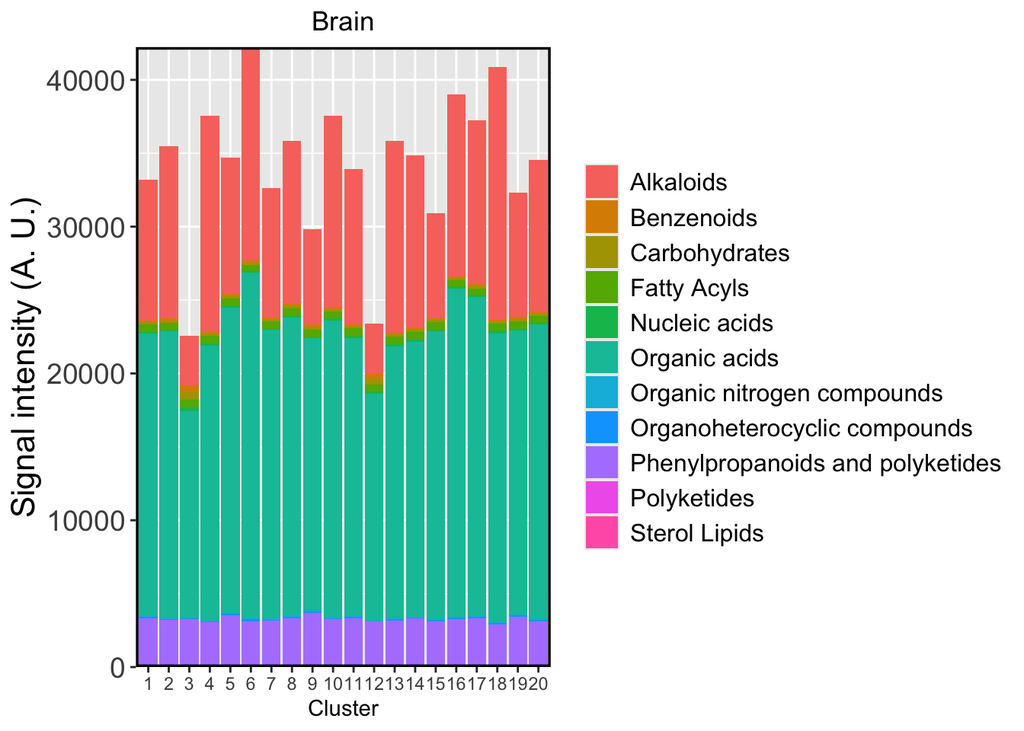

```r
# Reshape data for plotting
long_barplot1 <- summarized_for_barplot |>
    pivot_longer(cols = starts_with("Intensity"),
                 names_to = "Cluster",
                 values_to = "Intensity") |>
    mutate(
        Cluster = sub("Intensity\\.cluster", "", Cluster),
        Cluster = factor(Cluster, levels = as.character(1:20))
    )

# Create the stacked bar plot
p1 <- ggplot(long_barplot1, aes(x = Cluster, y = Intensity, fill = Superclass)) +
    geom_bar(stat = "identity", position = "stack") +
    labs(
        title = "Brain",
        x = "Cluster",
        y = "Intensity",
        fill = "Superclass"
    ) +
    scale_y_continuous(name = "Signal intensity (A. U.)", expand = c(0, 0)) +
    theme(
      axis.text.x = element_text(angle = 0, hjust = 0.5),
      axis.text.y = element_text(size = 14),
      axis.title.y = element_text(size = 16),
      plot.title = element_text(hjust = 0.5),
      legend.title = element_blank(),
      legend.text = element_text(size = 12),
      panel.border = element_rect(color = "black", fill = NA, size = 1.2)
      )
# Save the plot as a PDF
ggsave(p1, filename = "../../Results/4C_brain/4C_brain.pdf", width = 7, height = 4)

# Preview plot
print(p1)
```